# More on Bayes Factors

Andy Wills and Chris Berry

# Contents

- Further explanation of `ttestBF` output
- How to interpret a Bayes Factor
- When p-values and Bayes Factors disagree
- How likely is the null hypothesis?
- Further explanation of `anovaBF1 output

# Further explanation of `ttestBF` output

In the Evidence worksheet, we did the following Bayesian t-test:

```r
ttestBF(formula = income ~ sex, data = data.frame(cpsdata))
```

```
Bayes factor analysis
--------------
[1] Alt., r=0.707 : 18.25138 ±0%

Against denominator:
  Null, mu1-mu2 = 0
---
Bayes factor type: BFindepSample, JZS
```

Here’s a more detailed explanation of the output of that test – we’ll go through each bit in turn:

`Bayes factor analysis` - You’re doing a Bayes Factor analysis.

`[1] Alt., r=0.707` - In order to calculate a Bayes Factor, R has to make some assumptions about how big the difference is likely to be. The `ttestBF` command makes some broad assumptions that cover the range of effect sizes typically seen in psychology.

More specifically, `ttestBF` assumes a Cauchy distribution of effect sizes centered on zero, with a scale of 0.707 – this is where `r=0.707` comes from. That description probably didn’t make much sense useless you have a very strong maths background, so here’s the same idea, shown as a density plot. It’s basically an assumption that small effect sizes are quite likely, and large effect sizes are quite unlikely.

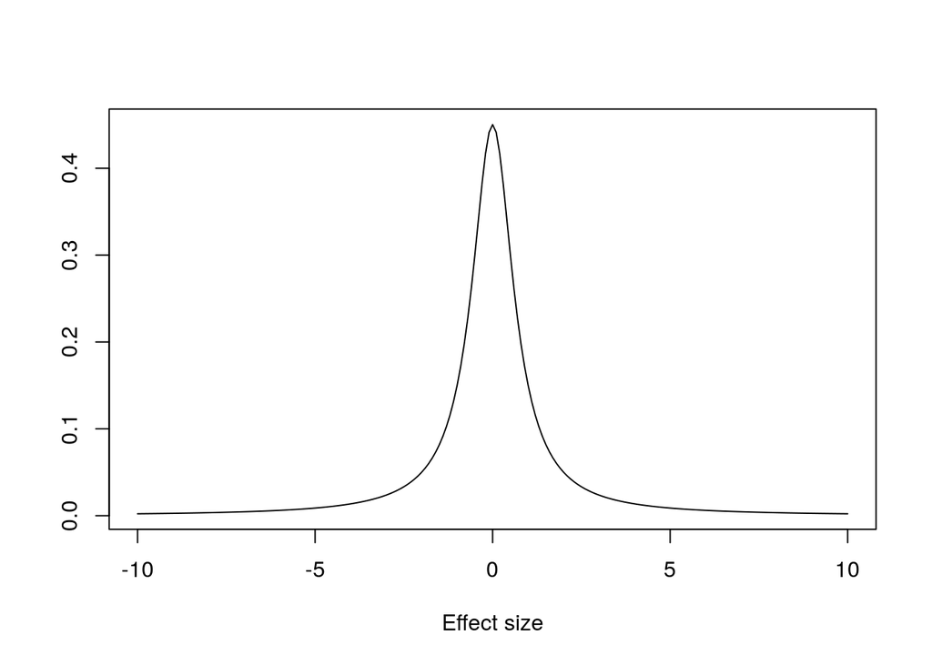

`18.25138` - The Bayes Factor (i.e. the main result of this analysis). See the next section for further discussion

`±0%` - Basically a confidence interval on the Bayes Factor. It’s 0% here because we have so much data, but with smaller samples we might see something like `20 ±5%`, which would means the Bayes Factor is about 20, give or take 5%. So, it’s between 19 and 21.

`Against denominator:` - This tells you that the null hypothesis is the denominator of the fraction that is used to calculate the Bayes Factor. So, in other words, you’re getting BF<sub>10</sub> rather than BF<sub>01</sub> – see the Evidence worksheet.

`Null, mu1-mu2 = 0` - This tells you that the null hypothesis is that the difference between the two group means (called `mu1` and `mu2` here) is zero.

`Bayes factor type: BFindepSample` - You’re doing a Bayes Factor analysis; `indepSample` is short for `independent samples`, which is another way of saying “between-subjects test”. `JZS` is short for Jeffreys, Zellner, and Siow - the surnames of three people who are credited with coming up with this particular way of working out Bayes Factors.